# Assignment 5

Nicholas Irons [njirons@uw.edu]

2022-02-09

# 1 HFD exploration

Get country codes and define functions to pull data from HFD:

```r
# HFD country codes
hfdcodes <- getHFDcountries() %>% tibble(ccode = .)

# ISO country codes
isocodes <- ISO_3166_1 %>% tibble() %>% select(ccode = Alpha_3, Name)

# join ISO codes with country names
hfdcodes <- hfdcodes %>% left_join(isocodes, by = "ccode")

# update missing country names
hfdcodes <- hfdcodes %>%
    mutate(Name =
        case_when(ccode == "FRATNP" ~  "France",
                  ccode == "DEUTNP" ~  "Germany",
                  ccode == "DEUTE" ~   "East Germany",
                  ccode == "DEUTW" ~   "West Germany",
                  ccode == "GBR_NP" ~  "United Kingdom",
                  ccode == "GBRTENW" ~ "England and Wales",
                  ccode == "GBR_SCO" ~ "Scotland",
                  ccode == "GBR_NIR" ~ "Northern Ireland",
                  TRUE ~ Name)
    )

# a function to read HFD for one country and one item
read_hfd_country <- function(CNTRY, item) {
  HMDHFDplus::readHFDweb(
    # the country from the function call
    CNTRY = CNTRY,
    # the item to download
    item = item,
    # the username from this key's record
    username = keyring::key_list("human-fertility-database")$username,
    # the password for this key's record
    password = keyring::key_get(
      service = "human-fertility-database",
      username = keyring::key_list("human-fertility-database")$username
    )
  )
}

# Download a data set iteratively for all named countries using purrr::map()
read_hfd_countries_item <- function(countries, item){
    countries %>%
        # Returns a list of data.frames, adding a column for country code to each
        # the map() function performs a run of Ben's read_hmd_country()
        #   function for each listed country
        purrr::map_dfr(function(ccode) {
            # read item
            read_hfd_country(ccode, item) %>%
                # this adds the column "country" storing the country ISO code
                dplyr::mutate(ccode = ccode)
        }) %>%
        # Phil added this to make it a tibble
        tibble() %>%
        # and add country name
        left_join(hfdcodes, by = "ccode")
}
```

Pull CBR and TFR data for United States, Lithuania, and Japan:

```r
# look at US, Lithuania, Japan
countries <- hfdcodes %>%
    filter(Name %in% c("United States", "Lithuania", "Japan")) %>%
    pull(ccode)

# call crude birth rates
cbr <- read_hfd_countries_item(countries = countries, item = "cbrRR")

# call total fertility rates
tfr <- read_hfd_countries_item(countries = countries, item = "tfrRR")

# combine datasets
df <- cbr %>% left_join(tfr, by = c("Year","Name","ccode"))
```

Plot CBR and TFR over time in each country:

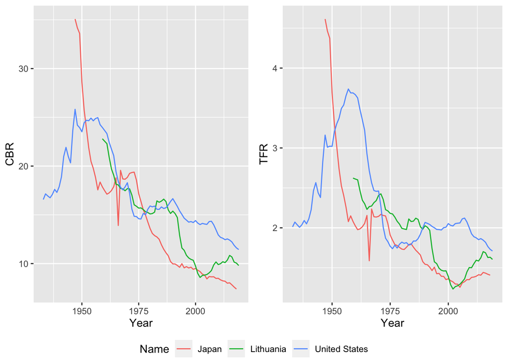

```r
# plot CBR over time
cbr_plot <- qplot(Year,CBR,data=df,color = Name,geom="line")

# plot TFR over time
tfr_plot <- qplot(Year,TFR,data=df,color = Name,geom="line")

# arrange plots in a nice layout
ggarrange(cbr_plot, tfr_plot,ncol = 2, nrow = 1,common.legend = TRUE, legend="bottom")
```

*Figure 1: Yearly CBR and TFR in 3 countries.*

From Figure 1 we see a general trend of declining crude birth rates and total fertility rates. However, these two measures are not exact proxies for each other. Total fertility rates do not depend on age-structure; they are calculated as a sum of age-specific fertility rates. On the other hand, crude birth rates depend on population structure: populations with more women of childbearing age will experience higher birth rates when controlling for total fertility rates. To get a sense of the different information encoded in these rates, we now plot the ratio of CBR and TFR over time in each country:

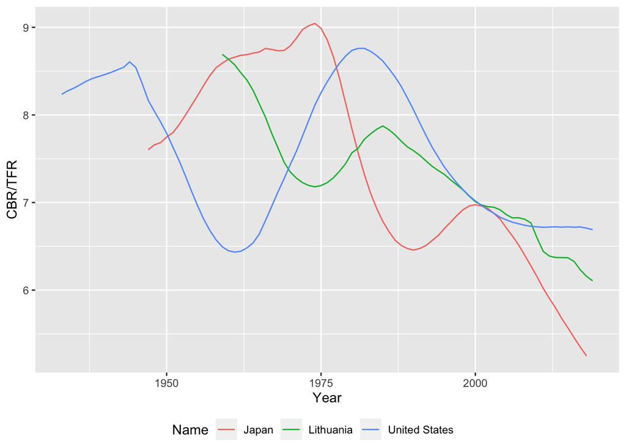

```r
# plot ratio CBR/TFR over time
ratio <- qplot(Year,CBR/TFR,data=df,color = Name,geom="line")
ggarrange(ratio,ncol = 1, nrow = 1,common.legend = TRUE, legend="bottom")
```

*Figure 2: Ratio CBR/TFR in 3 countries.*

From Figure 2, we see a declining trend in Lithuania and Japan, meaning that CBR has been declining relative to TFR. We see more of an oscillating trend in the US, with the oscillation on the downswing in the last few decades. In light of the discussion in the last paragraph, these trends align with common demographic knowledge about these populations. Namely, Japan and many European countries, including Lithuania, are facing a demographic crisis caused by declining fertility, which has resulted in an aging population. This is also true to some extent in the US and North America, although populations in these countries remain younger with higher fertility. In the US we see that TFR has remained relatively constant since 1975, while TFR in Japan and Lithuania have increased since 2000. Simultaneously, the ratio CBR/TFR has been generally declining in these time periods, which is reflective of the older populations in these countries yielding relatively fewer births, even though fertility is constant or on the rise.

# 2 Source code

```r
knitr::opts_chunk$set(echo = TRUE)

library(ISOcodes)
library(HMDHFDplus)
library(tidyverse)
library(keyring)
library(ggpubr)

library(captioner)
table_nums <- captioner(prefix = "Table")
figure_nums <- captioner(prefix = "Figure")
# HFD country codes
hfdcodes <- getHFDcountries() %>% tibble(ccode = .)

# ISO country codes
isocodes <- ISO_3166_1 %>% tibble() %>% select(ccode = Alpha_3, Name)

# join ISO codes with country names
hfdcodes <- hfdcodes %>% left_join(isocodes, by = "ccode")

# update missing country names
hfdcodes <- hfdcodes %>%
    mutate(Name =
        case_when(ccode == "FRATNP" ~  "France",
                  ccode == "DEUTNP" ~  "Germany",
                  ccode == "DEUTE" ~   "East Germany",
                  ccode == "DEUTW" ~   "West Germany",
                  ccode == "GBR_NP" ~  "United Kingdom",
                  ccode == "GBRTENW" ~ "England and Wales",
                  ccode == "GBR_SCO" ~ "Scotland",
                  ccode == "GBR_NIR" ~ "Northern Ireland",
                  TRUE ~ Name)
    )

# a function to read HFD for one country and one item
read_hfd_country <- function(CNTRY, item) {
  HMDHFDplus::readHFDweb(
    # the country from the function call
    CNTRY = CNTRY,
    # the item to download
    item = item,
    # the username from this key's record
    username = keyring::key_list("human-fertility-database")$username,
    # the password for this key's record
    password = keyring::key_get(
      service = "human-fertility-database",
      username = keyring::key_list("human-fertility-database")$username
    )
  )
}

# Download a data set iteratively for all named countries using purrr::map()
read_hfd_countries_item <- function(countries, item){
    countries %>%
        # Returns a list of data.frames, adding a column for country code to each
        # the map() function performs a run of Ben's read_hmd_country()
        #   function for each listed country
        purrr::map_dfr(function(ccode) {
            # read item
            read_hfd_country(ccode, item) %>%
                # this adds the column "country" storing the country ISO code
                dplyr::mutate(ccode = ccode)
        }) %>%
        # Phil added this to make it a tibble
        tibble() %>%
        # and add country name
        left_join(hfdcodes, by = "ccode")
}
# look at US, Lithuania, Japan
countries <- hfdcodes %>%
    filter(Name %in% c("United States", "Lithuania", "Japan")) %>%
    pull(ccode)

# call crude birth rates
cbr <- read_hfd_countries_item(countries = countries, item = "cbrRR")

# call total fertility rates
tfr <- read_hfd_countries_item(countries = countries, item = "tfrRR")

# combine datasets
df <- cbr %>% left_join(tfr, by = c("Year","Name","ccode"))
# plot CBR over time
cbr_plot <- qplot(Year,CBR,data=df,color = Name,geom="line")

# plot TFR over time
tfr_plot <- qplot(Year,TFR,data=df,color = Name,geom="line")

# arrange plots in a nice layout
ggarrange(cbr_plot, tfr_plot,ncol = 2, nrow = 1,common.legend = TRUE, legend="bottom")
# plot ratio CBR/TFR over time
ratio <- qplot(Year,CBR/TFR,data=df,color = Name,geom="line")
ggarrange(ratio,ncol = 1, nrow = 1,common.legend = TRUE, legend="bottom")
```